# 1) Estimating Power in Linear Mixed Models (lme4)

### Article: Estimating power in (generalized) linear mixed models: An open introdution and tutorial in R.

by Levi Kumle, Melissa L. H. Vo, and Dejan Draschkow (2021)

The function of this document is to write up the code from the paper above and detail how the simulation process for a power analysis works. We are creating thos document mostly to use as a reference but also to debug many code problems present in the original R code provuded by the authors. The original code is available below:

- Notebook 1: https://lkumle.github.io/power_notebooks/Scenario1_notebook.html
- Notebook 2: https://lkumle.github.io/power_notebooks/Scenario2_notebook.html
- Notebook 3: https://lkumle.github.io/power_notebooks/Scenario3_notebook.html

```r
# Doaload if needed
#devtools::install_github("DejanDraschkow/mixedpower")

# load in packages
library(languageR) #lexdec dataset
library(psych) # describe
library(lme4) # glmer()
library(simr) # makeGlmer()
library(mixedpower) # mixedpower()
library(dplyr)
library(ggplot2)
library(here)
```

## Part 3: Simulating power by generating data from scratch

#### 3.1 Exploring the data

If there is no available good dataset to use to estimate power, then the next best choice is to build the data and the model **from scratch**. However, we need to be very cautious when doing this because any mispecification will result in incorrect power estimation. Essentially, when will need to figure out the following to simulate the data.

- fixed-effect coefficients
- variance components associated with the random effects

For demonstrations, we will be using the *lexdec* dataet from the *languageR* package.

```r
# Keep only variable of interest
dat <- select(lexdec, Subject, Word, NativeLanguage, Frequency, Correct)

# Center the covariate
dat <- mutate(dat, CenteredFrequency = Frequency - mean(Frequency))

# Get to know our data
head(dat)
```

```
  Subject       Word NativeLanguage Frequency Correct CenteredFrequency
1      A1        owl        English  4.859812 correct        0.10870184
2      A1       mole        English  4.605170 correct       -0.14594016
3      A1     cherry        English  4.997212 correct        0.24610184
4      A1       pear        English  4.727388 correct       -0.02372216
5      A1        dog        English  7.667626 correct        2.91651584
6      A1 blackberry        English  4.060443 correct       -0.69066716
```

```r
str(dat)
```

```
'data.frame':   1659 obs. of  6 variables:
 $ Subject          : Factor w/ 21 levels "A1","A2","A3",..: 1 1 1 1 1 1 1 1 1 1 ...
 $ Word             : Factor w/ 79 levels "almond","ant",..: 55 47 20 58 25 12 71 69 62 1 ...
 $ NativeLanguage   : Factor w/ 2 levels "English","Other": 1 1 1 1 1 1 1 1 1 1 ...
 $ Frequency        : num  4.86 4.61 5 4.73 7.67 ...
 $ Correct          : Factor w/ 2 levels "correct","incorrect": 1 1 1 1 1 1 1 1 1 1 ...
 $ CenteredFrequency: num  0.1087 -0.1459 0.2461 -0.0237 2.9165 ...
```

```r
describe(dat)
```

```
                  vars    n  mean    sd median trimmed   mad   min   max range
Subject*             1 1659 11.00  6.06  11.00   11.00  7.41  1.00 21.00 20.00
Word*                2 1659 40.00 22.81  40.00   40.00 29.65  1.00 79.00 78.00
NativeLanguage*      3 1659  1.43  0.50   1.00    1.41  0.00  1.00  2.00  1.00
Frequency            4 1659  4.75  1.28   4.75    4.76  1.30  1.79  7.77  5.98
Correct*             5 1659  1.04  0.19   1.00    1.00  0.00  1.00  2.00  1.00
CenteredFrequency    6 1659  0.00  1.28   0.00    0.01  1.30 -2.96  3.02  5.98
                   skew kurtosis   se
Subject*           0.00    -1.21 0.15
Word*              0.00    -1.20 0.56
NativeLanguage*    0.29    -1.92 0.01
Frequency         -0.04    -0.37 0.03
Correct*           4.75    20.54 0.00
CenteredFrequency -0.04    -0.37 0.03
```

```r
# Unique factor levels for random variables
length(unique(dat$Subject))
```

```
[1] 21
```

```r
length(unique(dat$Word))
```

```
[1] 79
```

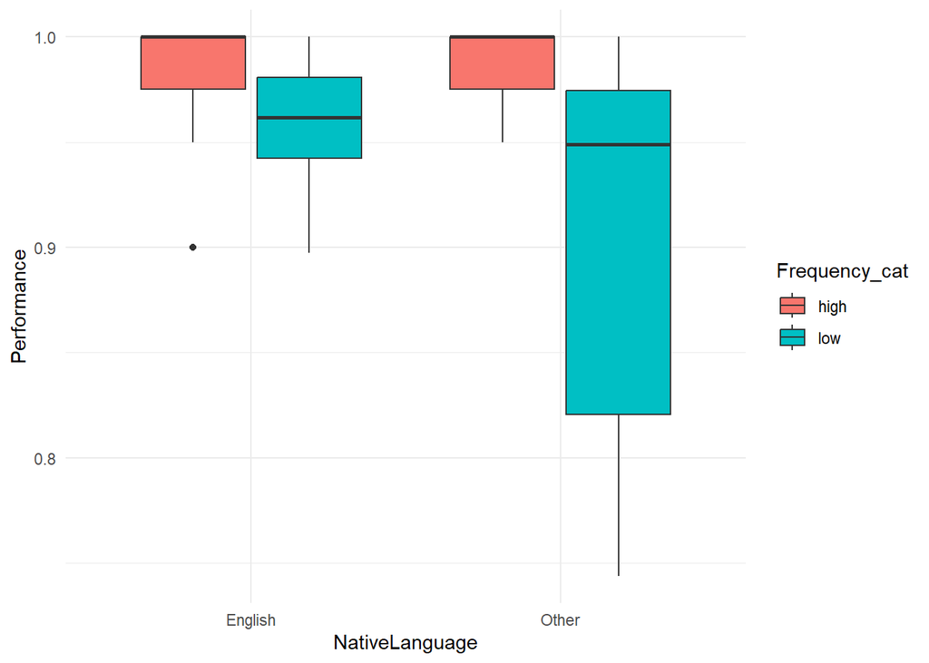

```r
# Visualize how the variables relate to the outcome
dat %>%
  mutate(Frequency_cat = ifelse(CenteredFrequency < 0, "low", "high")) %>%
  group_by(Subject, Frequency_cat, NativeLanguage) %>%
  summarise(Performance = mean(Correct == "correct")) %>%
  ggplot(aes(x = NativeLanguage, y = Performance, fill = Frequency_cat)) +
  geom_boxplot() +
  theme_minimal()
```

Looking at our lexdec dataset we see that we have 21 participants, 79 unique words, and when looking at performance, which we aggregated into proportion of correct trials, the common words (high frequency) are typically performed well between native and non-native speakers. However, although both speakers perform worse for the less common words (low frequency), the non native speakers take a much larger hit in performance and also show a lot more variability.

#### 3.2 Fitting a logistic mixed effects model

```r
# Fitting the glmer model to our data
modelY <- glmer(Correct ~ NativeLanguage * CenteredFrequency + (1 | Subject) + (1 | Word),
               family = "binomial", data = dat)

summary(modelY)
```

```
Generalized linear mixed model fit by maximum likelihood (Laplace
  Approximation) [glmerMod]
 Family: binomial  ( logit )
Formula: Correct ~ NativeLanguage * CenteredFrequency + (1 | Subject) +
    (1 | Word)
   Data: dat

      AIC       BIC    logLik -2*log(L)  df.resid
    497.1     529.6    -242.6     485.1      1653

Scaled residuals:
    Min      1Q  Median      3Q     Max
-1.0664 -0.1801 -0.1237 -0.0882  8.3312

Random effects:
 Groups  Name        Variance Std.Dev.
 Word    (Intercept) 1.0404   1.0200
 Subject (Intercept) 0.6578   0.8111
Number of obs: 1659, groups:  Word, 79; Subject, 21

Fixed effects:
                                      Estimate Std. Error z value Pr(>|z|)
(Intercept)                            -4.3076     0.4098 -10.512   <2e-16 ***
NativeLanguageOther                     0.3414     0.4926   0.693   0.4882
CenteredFrequency                      -0.3965     0.1887  -2.101   0.0357 *
NativeLanguageOther:CenteredFrequency  -0.3119     0.2175  -1.434   0.1516
---
Signif. codes:  0 '***' 0.001 '**' 0.01 '*' 0.05 '.' 0.1 ' ' 1

Correlation of Fixed Effects:
            (Intr) NtvLnO CntrdF
NtvLnggOthr -0.532
CntrdFrqncy  0.214 -0.141
NtvLnggO:CF -0.123  0.321 -0.567
```

#### 3.3 Building (simulating) a dataset from scratch (Design Matrix)

This section is just to create a dataframe that is fille with predictor information- **no outcome information**.

We are going to start by simulating a dataset with 20 subjects and 100 words. Obviously we can pick any other numbers but these are going to function as our starting point. We are then going to use the **expand.grid()** to function to fully cross our random variables.

```r
# 1. create subject IDs  -> let's start with 20 subjects
subject_ID <- (1:20)

# 2. create stimuli IDS -> every subject should read 100 words
stimuli_ID <- (1:100)

# 3. combine subject IDs and stimui IDs
artificial_data <- expand.grid(Subject = subject_ID, Word = stimuli_ID) %>%
  arrange(Subject)

# View the first few observations of the random var data
head(artificial_data)
```

```
  Subject Word
1       1    1
2       1    2
3       1    3
4       1    4
5       1    5
6       1    6
```

```r
# Check that the factors are crossed
xtabs(~Word + Subject, artificial_data) %>%
  head()
```

```
    Subject
Word 1 2 3 4 5 6 7 8 9 10 11 12 13 14 15 16 17 18 19 20
   1 1 1 1 1 1 1 1 1 1  1  1  1  1  1  1  1  1  1  1  1
   2 1 1 1 1 1 1 1 1 1  1  1  1  1  1  1  1  1  1  1  1
   3 1 1 1 1 1 1 1 1 1  1  1  1  1  1  1  1  1  1  1  1
   4 1 1 1 1 1 1 1 1 1  1  1  1  1  1  1  1  1  1  1  1
   5 1 1 1 1 1 1 1 1 1  1  1  1  1  1  1  1  1  1  1  1
   6 1 1 1 1 1 1 1 1 1  1  1  1  1  1  1  1  1  1  1  1
```

```r
# 1. create vector including identifier for native language
native_language <- c(rep(-0.5, 1000), rep(0.5, 1000))

# 2. add vector to data set
artificial_data["NativeLanguage"] <- native_language
```

Now we need to simulate the continuous covariate that corresponds to frequency ratings, or how common the presented word is. Looking back at the lexdec data, we can use the descriptives to note that the mean and standard deviation of frequencies is 4.7511102and 1.2750137 respectively. Thus we can use this information to randomly sample 100 observations (same number as the number of given words) from a normal distribution with a mean of 5 (similar to the data) and a standard deviation of 1 (also similar to our data).

After this vector is sampled, we will duplicate it for each participant, in other words repeat it 20 times. Then we can also incorporate its centered version as well.

```r
# Set seed for reproducibility
set.seed(123)

#  1. generate frequency ratings
frequency_ratings <- rnorm(100, mean = 5, sd = 1) # draw 100 frequency rating (one for every word)

# 2. add to data frame
artificial_data["Frequency"] <- rep(frequency_ratings, 20) # multiply by 20 (for every subject)
artificial_data$CenteredFrequency <- scale(artificial_data$Frequency, scale = F)
```

#### 3.4 Building a model from scratch

The essential goal to make power simulation work is to have a model object. However, we have a problem, we do not have an outcome in our data. So instead, we will use the makeGlmer() to essentially generate a model object without us needing an outcome, and we do this by prodiving the data skeleton along with the fixed and random effect parameters that we think best explain the relationship of the predictors the the outcome, which we got from our initial model fitting to the lexdec dataset.

This also bypasses our initial problem of running a power analysis on our original data, because that would result in us using our model object from our sample. Notice that here, we actually constructed the data skeleton with code, with inspiration from the raw data, and then used some information from the original model for our fixed effects.

```r
# 1. Extract the fixed effects from the model
fixed_effects <- fixef(modelY)
names(fixed_effects) <- NULL

# 2. Extract the variances of the random effects
vc <- VarCorr(modelY)
random_variance <- list(vc$Word[1], vc$Subject[1])

# #. Generate simulated predicted values
artificial_glmer <- makeGlmer(formula = Correct ~ NativeLanguage * CenteredFrequency + (1 | Subject)+ (1 | Word),
                              family = "binomial",
                              fixef = fixed_effects,
                              VarCorr = random_variance,
                              data = artificial_data)

# lets have a look!
summary(artificial_glmer)
```

```
Generalized linear mixed model fit by maximum likelihood (Laplace
  Approximation) [glmerMod]
 Family: binomial  ( logit )
Formula: Correct ~ NativeLanguage * CenteredFrequency + (1 | Subject) +
    (1 | Word)
   Data: artificial_data

      AIC       BIC    logLik -2*log(L)  df.resid
    789.2     822.8    -388.6     777.2      1994

Scaled residuals:
    Min      1Q  Median      3Q     Max
-1.0786 -0.2732 -0.2302 -0.2001  4.2348

Random effects:
 Groups  Name        Variance Std.Dev.
 Word    (Intercept) 1.0404   1.0200
 Subject (Intercept) 0.6578   0.8111
Number of obs: 2000, groups:  Word, 100; Subject, 20

Fixed effects:
                                 Estimate Std. Error z value Pr(>|z|)
(Intercept)                       -4.3076     0.2314 -18.620   <2e-16 ***
NativeLanguage                     0.3414     0.4119   0.829   0.4072
CenteredFrequency                 -0.3965     0.1547  -2.564   0.0104 *
NativeLanguage:CenteredFrequency  -0.3119     0.2032  -1.535   0.1248
---
Signif. codes:  0 '***' 0.001 '**' 0.01 '*' 0.05 '.' 0.1 ' ' 1

Correlation of Fixed Effects:
            (Intr) NtvLng CntrdF
NativeLangg -0.013
CntrdFrqncy  0.028 -0.003
NtvLngg:CnF -0.005  0.067 -0.039
```

#### 3.5 Power analysis

Now that we have the data and a model fit to it, we can actually start the power analysis. There are two ways to do it in the provided source. The first is to use functions from the *simr* package and the other is to use the **mixedpower()** function from the *mixedpower* package, available through devtools.

```r
####### Skipping simr for now but you can look it up in the Notebooks

####### Mixed Power

# Specify parameters about the simulation processes
steps <- c(20, 40, 60, 80) # which sample sizes do we want to look at?
critical_value <- 2 # which t/z value do we want to use to test for significance?
n_sim <- 1000 # how many single simulations should be used to estimate power?

# RUN SIMULATION
#power_FLP <- mixedpower(model = artificial_glmer,
#                        data = artificial_data,
#                        fixed_effects = c("NativeLanguage", "CenteredFrequency"),
#                        simvar = "Subject",
#                        steps = steps,
#                        critical_value = critical_value,
#                        n_sim = n_sim)

# Save the output:
#saveRDS(power_FLP, here("R_power_examples", "output", "power_FLP.Rds"))

# Load the simulation analysis from mixedpower
power_FLP <- readRDS(here("R_power_examples", "output", "power_FLP.Rds"))

# Show the power analysis output
power_FLP
```

```
                                    20    40    60    80      mode
NativeLanguage                   0.138 0.191 0.216 0.302 databased
CenteredFrequency                0.446 0.754 0.909 0.961 databased
NativeLanguage:CenteredFrequency 0.147 0.278 0.374 0.459 databased
                                                           effect
NativeLanguage                                     NativeLanguage
CenteredFrequency                               CenteredFrequency
NativeLanguage:CenteredFrequency NativeLanguage:CenteredFrequency
```